# Machine Utilization- Advanced R Practice

### Submission by Connor Lenio. Email: cojamalo@gmail.com

Completion Date: May 7, 2017

## Assignment

You have been engaged as a Data Science consultant by a coal terminal. They would like you to investigate one of their heavy machines - RL1

You have been supplied one month worth of data for all of their machines. The dataset shows what percentage of capacity for each machine was idle (unused) in any given hour. You are required to deliver an R list with the following components:

- Character: Machine name
- Vector: (min, mean, max) utilisation for the month (excluding unknown hours)
- Logical: Has utilisation ever fallen below 90%? TRUE / FALSE
- Vector: All hours where utilisation is unknown (NA’s)
- Dataframe: For this machine
- Plot: For all machines

## Data

Import the needed packages:

```r
library(data.table)
library(lubridate)
library(ggplot2)
library(dplyr)
```

Read the data into R using fread:

```r
all_data <- fread("Machine-Utilization.csv", na.strings = "", showProgress = FALSE) %>% tbl_df
```

### Data Cleaning

Convert `Timestamp` to date time, factor `Machine`, calculate `Utilization` using `Percent Idle`, and create the `Hour` variable for all timestamps:

```r
all_data$Timestamp <- dmy_hm(all_data$Timestamp)
all_data$Machine <- factor(all_data$Machine)
all_data$Utilization <- 1-all_data$`Percent Idle`
all_data <- all_data %>% mutate(Hour = hour(Timestamp))
```

### Construct the List

The list is constructed using a simple “for” loop that calculates the desired statistics for each machine in the data. The result is `final_list`:

```r
six <- ggplot(all_data, aes(x=Timestamp, y = Utilization, color = Machine)) + geom_line() + facet_grid(Machine~.)
final_list <- NULL
i <- 1
for (machine in levels(all_data$Machine)) {
    mach_data <- all_data %>% filter(Machine == machine)
    downhr <- mach_data %>% filter(is.na(Utilization))
    downhr <- downhr$Timestamp
    new_row <- list(Machine = machine, Min_Util = min(mach_data$Utilization, na.rm= TRUE), Mean_Util = mean(mach_data$Utilization, na.rm= TRUE), Max_Util = max(mach_data$Utilization, na.rm = TRUE), Util_Below_90 = ifelse(min(mach_data$Utilization, na.rm= TRUE) < 0.9, TRUE, FALSE),Down_Hours = downhr, Data = mach_data, Plot = six)
    final_list[[i]] <- new_row
    i <- i + 1
}
names(final_list) <- levels(all_data$Machine)
```

The top level of structure of `final_list` is a list of five sublists, one for each machine:

```r
summary(final_list)
```

```
##      Length Class  Mode
## RL1  8      -none- list
## RL2  8      -none- list
## SR1  8      -none- list
## SR4A 8      -none- list
## SR6  8      -none- list
```

The following is an example of one of these five sublists, shwoing the desired information and plots:

```r
final_list$RL1
```

```
## $Machine
## [1] "RL1"
##
## $Min_Util
## [1] 0.8492262
##
## $Mean_Util
## [1] 0.9516976
##
## $Max_Util
## [1] 0.995
##
## $Util_Below_90
## [1] TRUE
##
## $Down_Hours
## [1] "2016-09-01 00:00:00 UTC" "2016-09-01 01:00:00 UTC"
## [3] "2016-09-01 02:00:00 UTC" "2016-09-01 03:00:00 UTC"
## [5] "2016-09-01 04:00:00 UTC" "2016-09-01 05:00:00 UTC"
## [7] "2016-09-01 06:00:00 UTC"
##
## $Data
## # A tibble: 720 × 5
##              Timestamp Machine `Percent Idle` Utilization  Hour
##                 <dttm>  <fctr>          <dbl>       <dbl> <int>
## 1  2016-09-01 00:00:00     RL1             NA          NA     0
## 2  2016-09-01 01:00:00     RL1             NA          NA     1
## 3  2016-09-01 02:00:00     RL1             NA          NA     2
## 4  2016-09-01 03:00:00     RL1             NA          NA     3
## 5  2016-09-01 04:00:00     RL1             NA          NA     4
## 6  2016-09-01 05:00:00     RL1             NA          NA     5
## 7  2016-09-01 06:00:00     RL1             NA          NA     6
## 8  2016-09-01 07:00:00     RL1     0.01994048   0.9800595     7
## 9  2016-09-01 08:00:00     RL1     0.01997024   0.9800298     8
## 10 2016-09-01 09:00:00     RL1     0.02119048   0.9788095     9
## # ... with 710 more rows
##
## $Plot
```

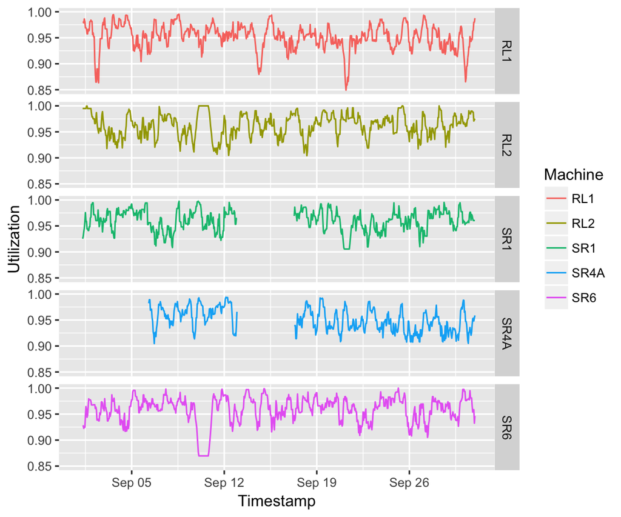